# Part 1 ‐ Exploratory data analysis

```python
import numpy as np
import pandas as pd
import seaborn as sns
import matplotlib as plt
import json
%matplotlib inline
import warnings
warnings.filterwarnings('ignore')
```

```python
df = pd.read_json('/Users/markoglodovic/Downloads/ultimate_challenge/logins.json')
```

```python
df.head()
```

|  | login_time |
| --- | --- |
| 0 | 1970-01-01 20:13:18 |
| 1 | 1970-01-01 20:16:10 |
| 2 | 1970-01-01 20:16:37 |
| 3 | 1970-01-01 20:16:36 |
| 4 | 1970-01-01 20:26:21 |

```python
df.info()
```

```
<class 'pandas.core.frame.DataFrame'>
RangeIndex: 93142 entries, 0 to 93141
Data columns (total 1 columns):
 #   Column      Non-Null Count  Dtype
---  ------      --------------  -----
 0   login_time  93142 non-null  datetime64[ns]
dtypes: datetime64[ns](1)
memory usage: 727.8 KB
```

```python
df.isnull().sum()
```

```
login_time    0
dtype: int64
```

```python
df.set_index('login_time', inplace=True)
df['count'] = 1
```

```python
df.head()
```

| login_time | count |
| --- | --- |
| 1970-01-01 20:13:18 | 1 |
| 1970-01-01 20:16:10 | 1 |
| 1970-01-01 20:16:37 | 1 |
| 1970-01-01 20:16:36 | 1 |
| 1970-01-01 20:26:21 | 1 |

```python
# Aggregate login counts based on 15-minute time intervals
df = df.resample('15T', label='right').sum()
df.head()
```

| login_time | count |
| --- | --- |
| 1970-01-01 20:15:00 | 2 |
| 1970-01-01 20:30:00 | 6 |
| 1970-01-01 20:45:00 | 9 |
| 1970-01-01 21:00:00 | 7 |
| 1970-01-01 21:15:00 | 1 |

```python
df.info()
```

```
<class 'pandas.core.frame.DataFrame'>
DatetimeIndex: 9788 entries, 1970-01-01 20:15:00 to 1970-04-13 19:00:00
Freq: 15T
Data columns (total 1 columns):
 #   Column  Non-Null Count  Dtype
---  ------  --------------  -----
 0   count   9788 non-null   int64
dtypes: int64(1)
memory usage: 152.9 KB
```

```python
df['time'] = pd.to_datetime(df.index)
```

```python
df['hour'] = df.time.dt.hour
df['day'] = df.time.dt.day
df['week'] = df.time.dt.week
df['month'] = df.time.dt.month
```

```python
df.head()
```

| login_time | count | time | hour | day | week | month |
| --- | --- | --- | --- | --- | --- | --- |
| 1970-01-01 20:15:00 | 2 | 1970-01-01 20:15:00 | 20 | 1 | 1 | 1 |
| 1970-01-01 20:30:00 | 6 | 1970-01-01 20:30:00 | 20 | 1 | 1 | 1 |
| 1970-01-01 20:45:00 | 9 | 1970-01-01 20:45:00 | 20 | 1 | 1 | 1 |
| 1970-01-01 21:00:00 | 7 | 1970-01-01 21:00:00 | 21 | 1 | 1 | 1 |
| 1970-01-01 21:15:00 | 1 | 1970-01-01 21:15:00 | 21 | 1 | 1 | 1 |

```python
import seaborn as sns
import matplotlib.pyplot as plt
```

## Login activities in different months

```python
print (df.groupby('month')['count'].aggregate(np.sum))
```

```
month
1    21225
2    24669
3    33727
4    13521
Name: count, dtype: int64
```

```python
dfm = df.groupby('month')['count'].sum()
dfm = dfm.to_frame().reset_index()
```

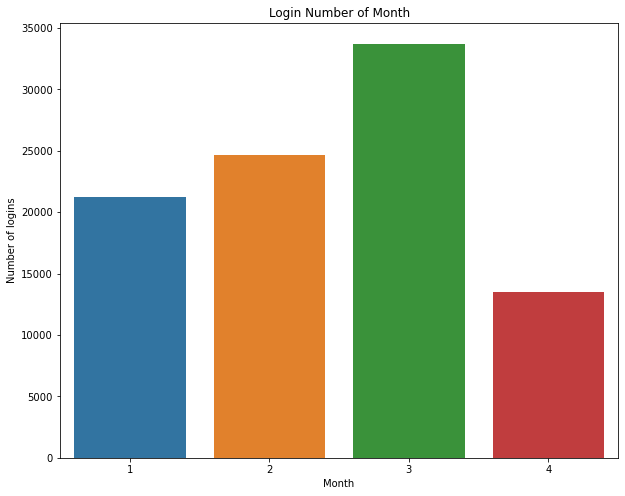

```python
fig, ax = plt.subplots(figsize=(10, 8))
sns.barplot(x = 'month', y = 'count' , data = dfm)
plt.title("Login Number of Month")
plt.xlabel("Month")
plt.ylabel("Number of logins")
```

### Numbers kept increasing from January to March. The login number of March is highest. We dont have data for whole april just for 13 days.

## Login activities in different weeks

```python
print (df.groupby('week')['count'].aggregate(np.sum))
```

```
week
1     2368
2     5218
3     5021
4     4750
5     4747
6     5564
7     5914
8     7038
9     6554
10    7400
11    7329
12    8959
13    7284
14    8096
15    6496
16     404
Name: count, dtype: int64
```

```python
dfw = df.groupby('week')['count'].sum()
dfw = dfw.to_frame().reset_index()
```

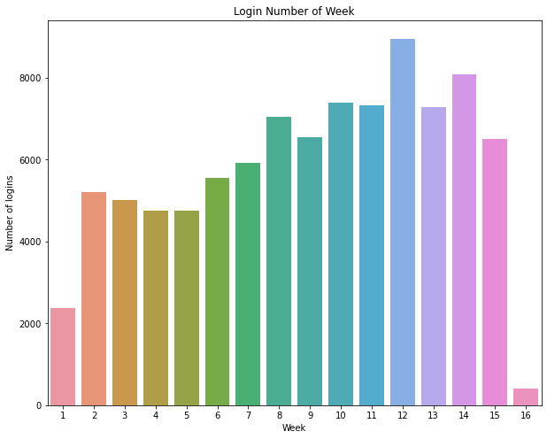

```python
fig, ax = plt.subplots(figsize=(10, 8))
sns.barplot(x = 'week', y = 'count' , data = dfw)
plt.title("Login Number of Week")
plt.xlabel("Week")
plt.ylabel("Number of logins")
```

### Logins in week 12 are the most, after that is in 14 week. So end of march and begining of april have the beiggest numbers.

## Login activities during the different weekdays

```python
df['weekday'] = df.time.dt.weekday
import calendar
nweek = 16   # total weeks
print ('[Grouping by weekday]')
print (df.groupby('weekday')['count'].aggregate(np.sum)/nweek)
```

```
[Grouping by weekday]
weekday
0     553.0625
1     576.6250
2     642.6250
3     746.9375
4     947.0000
5    1214.6250
6    1140.5000
Name: count, dtype: float64
```

```python
dfwd = df.groupby('weekday')['count'].aggregate(np.sum)/nweek
dfwd = dfwd.to_frame().reset_index()
```

[output not shown]

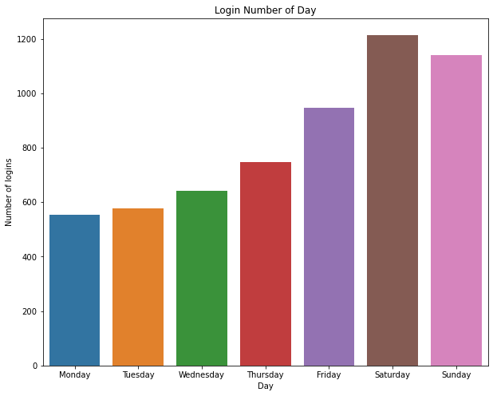

```python
fig, ax = plt.subplots(figsize=(10, 8))
sns.barplot(x = 'weekday', y = 'count' , data = dfwd)
plt.title("Login Number of Day")
plt.xlabel("Day")
plt.ylabel("Number of logins")
ax.set_xticklabels([calendar.day_name[d] for d in range(7)])
```

### Weekends have the bigger number of logins then weekdays. And Saturday is leading the way.

## Login activities per day

```python
# total days
nday = 30+28+30+13
dfd = (df.groupby('hour')['count'].sum()/nday)
dfd = dfd.to_frame().reset_index()
```

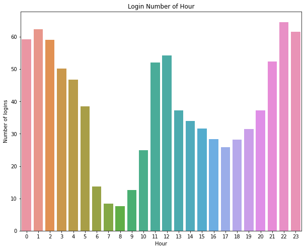

```python
fig, ax = plt.subplots(figsize=(10, 8))
sns.barplot(x = 'hour', y = 'count' , data = dfd)
plt.title("Login Number of Hour")
plt.xlabel("Hour")
plt.ylabel("Number of logins")
```

### Most logins are from 9 pm to 5 am, with a spike around noon.

```python
# Aggregate login counts based on 1-hour time intervals
df_hour = df.resample('H').sum()
df_hour.head()
```

| login_time | count | hour | day | week | month | weekday |
| --- | --- | --- | --- | --- | --- | --- |
| 1970-01-01 20:00:00 | 17 | 60 | 3 | 3 | 3 | 9 |
| 1970-01-01 21:00:00 | 12 | 84 | 4 | 4 | 4 | 12 |
| 1970-01-01 22:00:00 | 22 | 88 | 4 | 4 | 4 | 12 |
| 1970-01-01 23:00:00 | 46 | 92 | 4 | 4 | 4 | 12 |
| 1970-01-02 00:00:00 | 55 | 0 | 8 | 4 | 4 | 16 |

```python
df_hour['time'] = pd.to_datetime(df_hour.index)
df_hour['hour'] = df_hour.time.dt.hour
df_hour.head()
```

| login_time | count | hour | day | week | month | weekday | time |
| --- | --- | --- | --- | --- | --- | --- | --- |
| 1970-01-01 20:00:00 | 17 | 20 | 3 | 3 | 3 | 9 | 1970-01-01 20:00:00 |
| 1970-01-01 21:00:00 | 12 | 21 | 4 | 4 | 4 | 12 | 1970-01-01 21:00:00 |
| 1970-01-01 22:00:00 | 22 | 22 | 4 | 4 | 4 | 12 | 1970-01-01 22:00:00 |
| 1970-01-01 23:00:00 | 46 | 23 | 4 | 4 | 4 | 12 | 1970-01-01 23:00:00 |
| 1970-01-02 00:00:00 | 55 | 0 | 8 | 4 | 4 | 16 | 1970-01-02 00:00:00 |

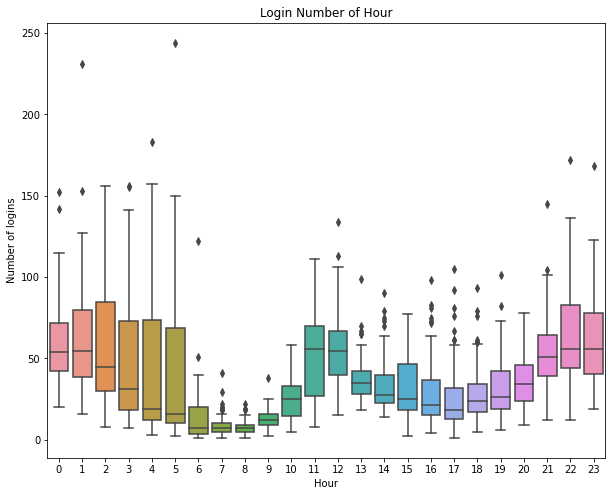

```python
sns.mpl.rc("figure", figsize=(10,8))
sns.boxplot(x='hour', y='count', data=df_hour)
plt.title("Login Number of Hour")
plt.xlabel("Hour")
plt.ylabel("Number of logins")
```

## 2. Logins in week 12 are the most, after that is in 14 week. So end of march and begining of april have the biggest numbers.

## 3. There are more logins during the weekends than during the weekdays. Saturday has the biggest numbers.

## 4. Most logins are from 9 pm to 5 am, with a spike around noon.

# Part 2 ‐ Experiment and metrics design

### The neighboring cities of Gotham and Metropolis have complementary circadian rhythms: on weekdays, Ultimate Gotham is most active at night, and Ultimate Metropolis is most active during the day. On weekends, there is reasonable activity in both cities.

However, a toll bridge, with a two way toll, between the two cities causes driver partners to tend to be exclusive to each city. The Ultimate managers of city operations for the two cities have proposed an experiment to encourage driver partners to be available in both cities, by reimbursing all toll costs. 1) What would you choose as the key measure of success of this experiment in encouraging driver partners to serve both cities, and why would you choose this metric?

2) Describe a practical experiment you would design to compare the effectiveness of the proposed change in relation to the key measure of success. Please provide details on:

a) how you will implement the experiment

b) what statistical test(s) you will conduct to verify the significance of the observation

c) how you would interpret the results and provide recommendations to the city operations team along with any caveats.

## Answers:

## 1. I Would choose revenue increase for the Ultimate Inc (the difference between total revenue minus reimbursed toll cost) like a key measure of succes.

## Main reason for chosing this metric, would be easy explanation of the experiment succes. If the total revenue increseas durung the experiment time, we would consider succes and if would stay similar of smaller then the previos sample we would consider experiment failed.

## 2. For the experiment, first I would need is minimum 4 weeks of collected data without reimbursed toll cost under normal conditions, and minimum 4 weeks of collected data with reimbursed toll cost for all drivers.

### The data we would collect is data of the total revenue, toll costs reimbursed, include date, time, cost, direction, driver parterns from which city they are coming from, available drivers, waiting time.

### Also some aditional metric for succes would be: 1. More available drivers 2. smaller waiting time.

### I would conduct couple of the Independent Group t-tests comparing the metrics from the experiment and from metrics from the data before the experiment.

### We would consider experiment succesfull if:

## Total revenue INCREASED compared to the period before we started reimbursing toll cost

### Wait time for drivers got SMALLER

### Total available drivers INCREASED

### For our recommendations for the experiment to be adopted is that revenue INCREASE is statistically significant and at least two weeks of the experiment have bigger total revenue comparing to the period before reimbursed toll cost.

# Part 3 ‐ Predictive modeling

## Data wrangling

Data description

● city: city this user signed up in

● phone: primary device for this user

● signup_date: date of account registration; in the form ‘YYYYMMDD’

● last_trip_date: the last time this user completed a trip; in the form ‘YYYYMMDD’

● avg_dist: the average distance in miles per trip taken in the first 30 days after signup

● avg_rating_by_driver: the rider’s average rating over all of their trips

● avg_rating_of_driver: the rider’s average rating of their drivers over all of their trips

● surge_pct: the percent of trips taken with surge multiplier > 1

● avg_surge: The average surge multiplier over all of this user’s trips

● trips_in_first_30_days: the number of trips this user took in the first 30 days after signing up

● ultimate_black_user: TRUE if the user took an Ultimate Black in their first 30 days; FALSE otherwise

● weekday_pct: the percent of the user’s trips occurring during a weekday

```python
# Read in the data
import json

file = open('/Users/markoglodovic/Downloads/ultimate_challenge/ultimate_data_challenge.json', 'r')
df = pd.DataFrame(json.load(file))
file.close()

df.head()
```

|  | city | trips_in_first_30_days | signup_date | avg_rating_of_driver | avg_surge | last_trip_date | phone | surge_pct | ultimate_black_user | weekday_pct | avg_dist | avg_rating_by_driver |
| --- | --- | --- | --- | --- | --- | --- | --- | --- | --- | --- | --- | --- |
| 0 | King's Landing | 4 | 2014-01-25 | 4.7 | 1.10 | 2014-06-17 | iPhone | 15.4 | True | 46.2 | 3.67 | 5.0 |
| 1 | Astapor | 0 | 2014-01-29 | 5.0 | 1.00 | 2014-05-05 | Android | 0.0 | False | 50.0 | 8.26 | 5.0 |
| 2 | Astapor | 3 | 2014-01-06 | 4.3 | 1.00 | 2014-01-07 | iPhone | 0.0 | False | 100.0 | 0.77 | 5.0 |
| 3 | King's Landing | 9 | 2014-01-10 | 4.6 | 1.14 | 2014-06-29 | iPhone | 20.0 | True | 80.0 | 2.36 | 4.9 |
| 4 | Winterfell | 14 | 2014-01-27 | 4.4 | 1.19 | 2014-03-15 | Android | 11.8 | False | 82.4 | 3.13 | 4.9 |

```python
df.columns
```

```
Index(['city', 'trips_in_first_30_days', 'signup_date', 'avg_rating_of_driver',
       'avg_surge', 'last_trip_date', 'phone', 'surge_pct',
       'ultimate_black_user', 'weekday_pct', 'avg_dist',
       'avg_rating_by_driver'],
      dtype='object')
```

```python
df.info()
```

```
<class 'pandas.core.frame.DataFrame'>
RangeIndex: 50000 entries, 0 to 49999
Data columns (total 12 columns):
 #   Column                  Non-Null Count  Dtype
---  ------                  --------------  -----
 0   city                    50000 non-null  object
 1   trips_in_first_30_days  50000 non-null  int64
 2   signup_date             50000 non-null  object
 3   avg_rating_of_driver    41878 non-null  float64
 4   avg_surge               50000 non-null  float64
 5   last_trip_date          50000 non-null  object
 6   phone                   49604 non-null  object
 7   surge_pct               50000 non-null  float64
 8   ultimate_black_user     50000 non-null  bool
 9   weekday_pct             50000 non-null  float64
 10  avg_dist                50000 non-null  float64
 11  avg_rating_by_driver    49799 non-null  float64
dtypes: bool(1), float64(6), int64(1), object(4)
memory usage: 4.2+ MB
```

```python
# Fill in missing values
df['avg_rating_by_driver'].fillna(df['avg_rating_by_driver'].mean(), inplace=True)
df['avg_rating_of_driver'].fillna(df['avg_rating_of_driver'].mean(), inplace=True)
df.dropna(axis=0, inplace=True)
```

```python
df = df.reset_index(drop=True)
```

```python
df.info()
```

```
<class 'pandas.core.frame.DataFrame'>
RangeIndex: 49604 entries, 0 to 49603
Data columns (total 12 columns):
 #   Column                  Non-Null Count  Dtype
---  ------                  --------------  -----
 0   city                    49604 non-null  object
 1   trips_in_first_30_days  49604 non-null  int64
 2   signup_date             49604 non-null  object
 3   avg_rating_of_driver    49604 non-null  float64
 4   avg_surge               49604 non-null  float64
 5   last_trip_date          49604 non-null  object
 6   phone                   49604 non-null  object
 7   surge_pct               49604 non-null  float64
 8   ultimate_black_user     49604 non-null  bool
 9   weekday_pct             49604 non-null  float64
 10  avg_dist                49604 non-null  float64
 11  avg_rating_by_driver    49604 non-null  float64
dtypes: bool(1), float64(6), int64(1), object(4)
memory usage: 4.2+ MB
```

```python
# Convert dates to datetime format
df['last_trip_date'] = pd.to_datetime(df['last_trip_date'])
df['signup_date'] = pd.to_datetime(df['signup_date'])
```

```python
df.info()
```

```
<class 'pandas.core.frame.DataFrame'>
RangeIndex: 49604 entries, 0 to 49603
Data columns (total 12 columns):
 #   Column                  Non-Null Count  Dtype
---  ------                  --------------  -----
 0   city                    49604 non-null  object
 1   trips_in_first_30_days  49604 non-null  int64
 2   signup_date             49604 non-null  datetime64[ns]
 3   avg_rating_of_driver    49604 non-null  float64
 4   avg_surge               49604 non-null  float64
 5   last_trip_date          49604 non-null  datetime64[ns]
 6   phone                   49604 non-null  object
 7   surge_pct               49604 non-null  float64
 8   ultimate_black_user     49604 non-null  bool
 9   weekday_pct             49604 non-null  float64
 10  avg_dist                49604 non-null  float64
 11  avg_rating_by_driver    49604 non-null  float64
dtypes: bool(1), datetime64[ns](2), float64(6), int64(1), object(2)
memory usage: 4.2+ MB
```

## Exploratory Data Analysis

```python
# Create box plots of all categorical, non-date data
categorical_features = ['city', 'phone', 'ultimate_black_user']
```

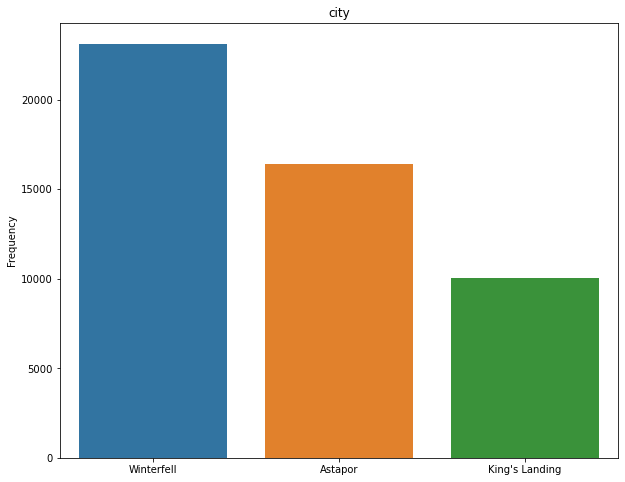

```
Winterfell        23125
Astapor           16413
King's Landing    10066
Name: city, dtype: int64
```

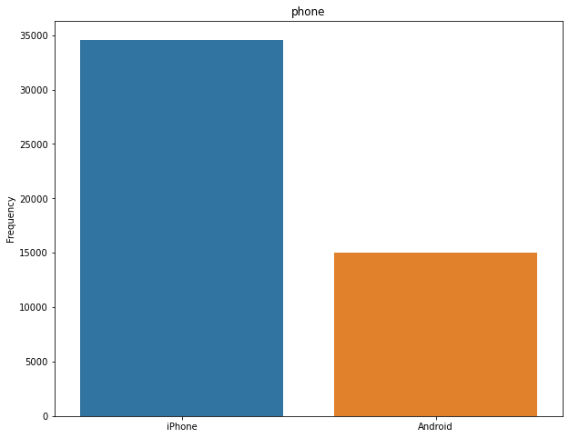

```
iPhone     34582
Android    15022
Name: phone, dtype: int64
```

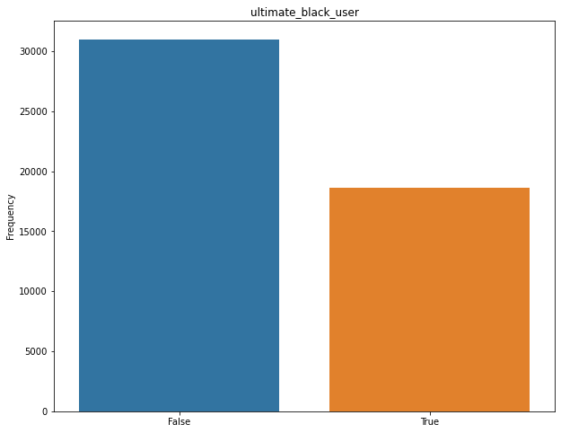

```
False    30992
True     18612
Name: ultimate_black_user, dtype: int64
```

```python
for feature in categorical_features:
    sns.barplot(x = list(df[feature].value_counts().index), y = df[feature].value_counts())
    plt.title(feature)
    plt.ylabel('Frequency')
    plt.show()
    print(df[feature].value_counts())
```

```python
# Show distributions of numerical features
numerical_features = ['avg_dist', 'avg_rating_by_driver', 'avg_rating_of_driver',
                      'avg_surge', 'surge_pct', 'trips_in_first_30_days', 'weekday_pct']
```

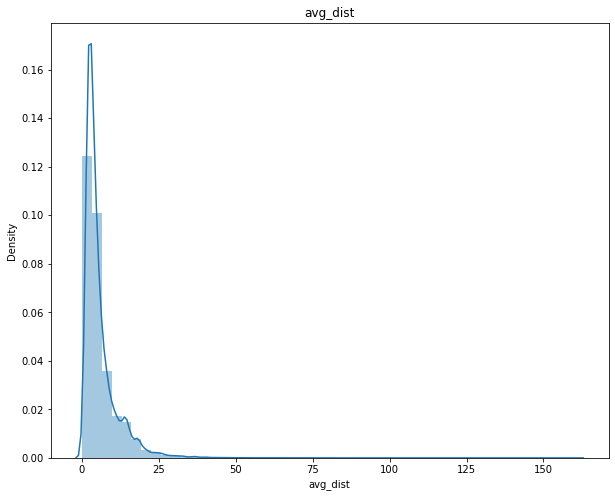

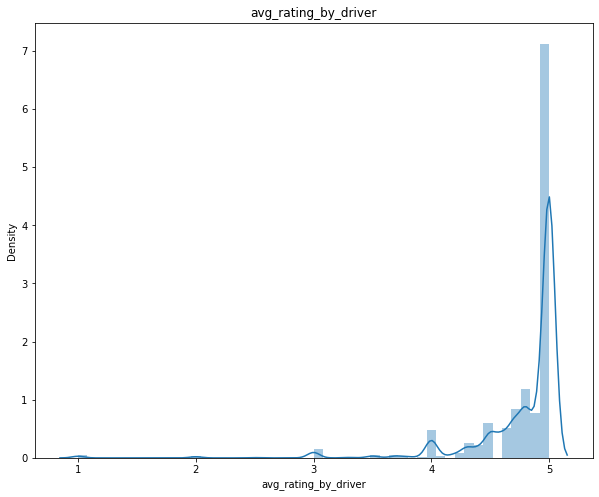

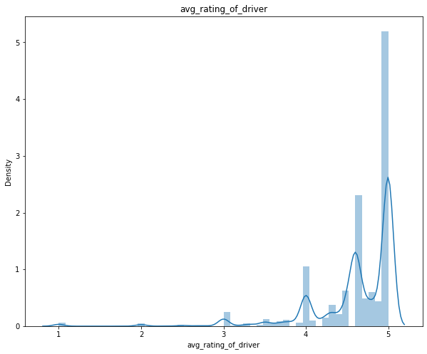

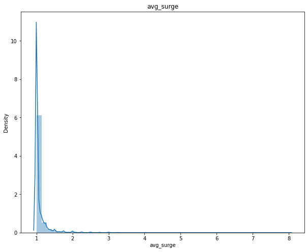

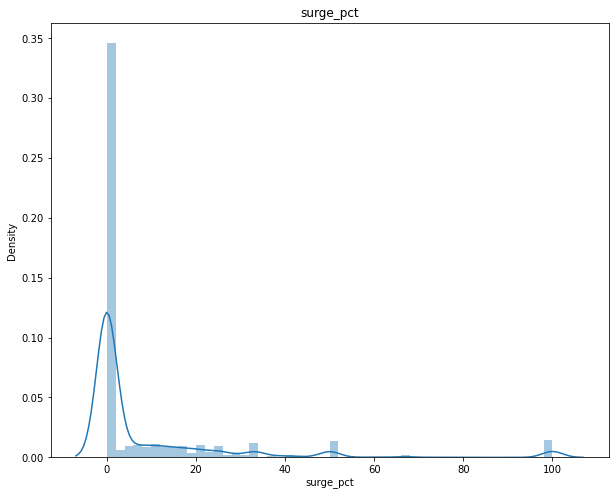

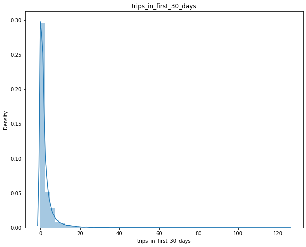

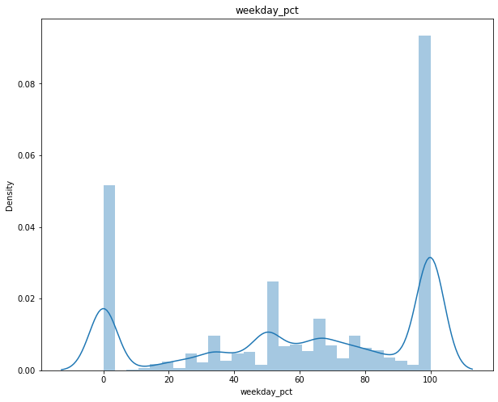

```python
for feature in numerical_features:
    sns.distplot(df[feature])
    plt.title(feature)
    plt.show();
```

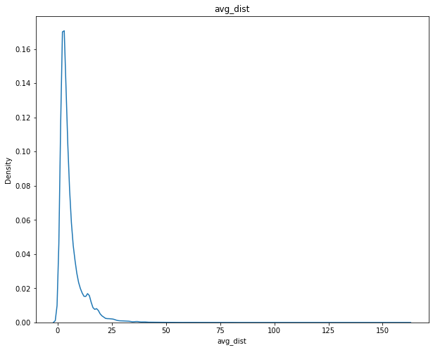

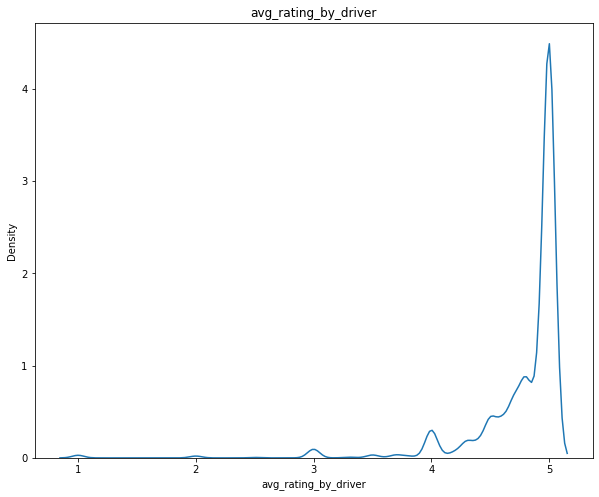

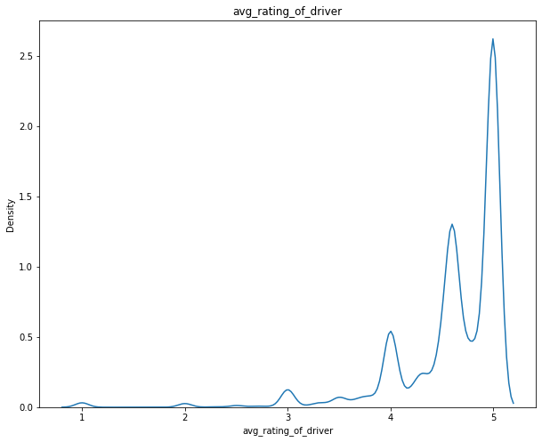

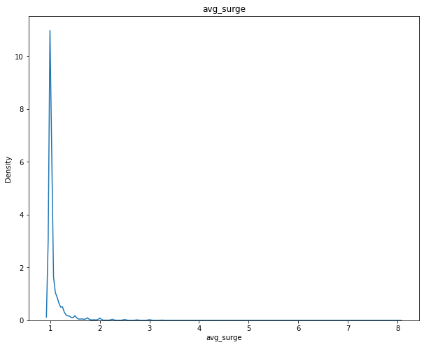

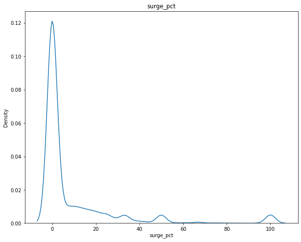

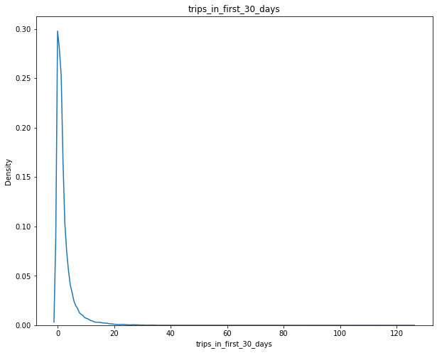

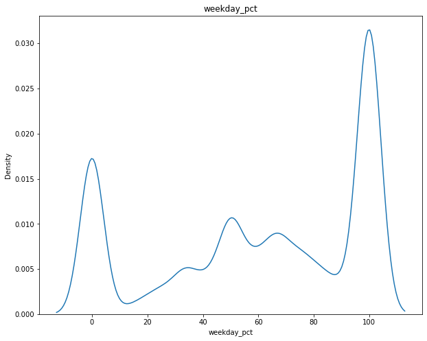

```python
for feature in numerical_features:
    sns.kdeplot(df[feature])
    plt.title(feature)
    plt.show();
```

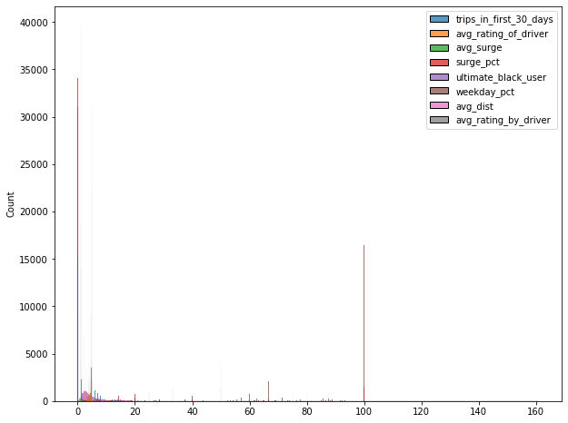

```python
sns.histplot(df)
```

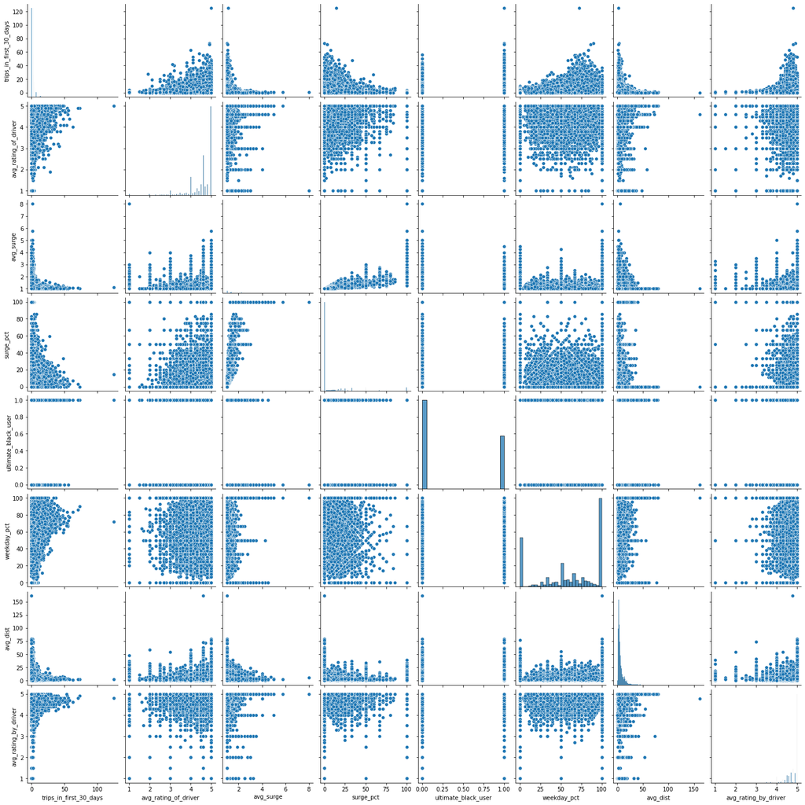

```python
sns.pairplot(df)
```

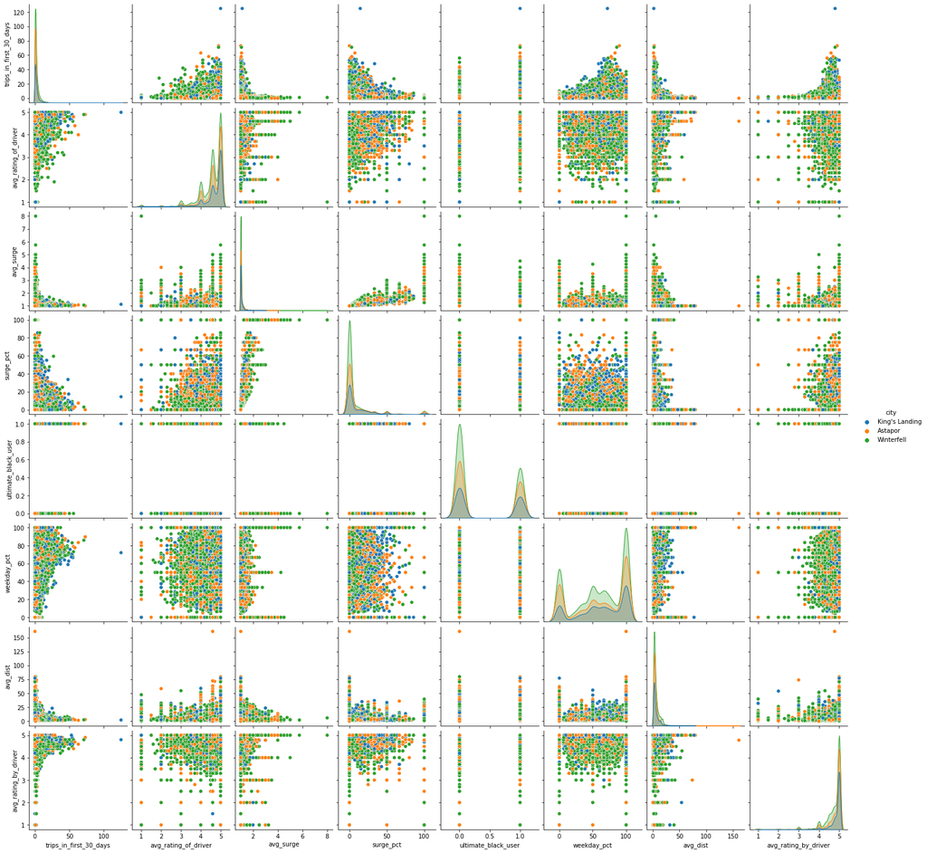

```python
sns.pairplot(df, hue='city')
```

```python
df.sort_values(by='last_trip_date').tail()
```

|  | city | trips_in_first_30_days | signup_date | avg_rating_of_driver | avg_surge | last_trip_date | phone | surge_pct | ultimate_black_user | weekday_pct | avg_dist | avg_rating_by_driver |
| --- | --- | --- | --- | --- | --- | --- | --- | --- | --- | --- | --- | --- |
| 45166 | King's Landing | 2 | 2014-01-25 | 4.4 | 1.14 | 2014-07-01 | Android | 17.9 | False | 83.9 | 2.32 | 4.8 |
| 12053 | King's Landing | 16 | 2014-01-18 | 4.9 | 1.02 | 2014-07-01 | Android | 3.9 | False | 74.0 | 2.64 | 4.8 |
| 18667 | Astapor | 3 | 2014-01-10 | 4.7 | 1.02 | 2014-07-01 | iPhone | 3.2 | False | 67.7 | 6.22 | 4.8 |
| 11999 | Winterfell | 1 | 2014-01-24 | 4.7 | 1.04 | 2014-07-01 | iPhone | 15.4 | True | 38.5 | 6.80 | 4.9 |
| 31351 | Winterfell | 12 | 2014-01-19 | 4.9 | 1.07 | 2014-07-01 | iPhone | 6.0 | True | 70.0 | 5.63 | 4.7 |

```python
df['last_trip_date'].sort_values().tail()
```

```
45166   2014-07-01
12053   2014-07-01
18667   2014-07-01
11999   2014-07-01
31351   2014-07-01
Name: last_trip_date, dtype: datetime64[ns]
```

### So the latest 'last_trip_date' is 2014-07-01. As we consider a user retained if they were “active” (i.e. took a trip) in the preceding 30 days, We consider a user retained if his 'last_trip_date' is after 2014-06-01.

```python
frac = len(df[df['last_trip_date'] > '2014-06-01'])/len(df)
print('{:.2f}% of the observed users were retained.'.format(frac*100))
```

```
36.65% of the observed users were retained.
```

## Data Modeling

```python
# Create the target variable -- retained

df['retained'] = (df['last_trip_date'] > '2014-06-01')*1
```

```python
df.head()
```

|  | city | trips_in_first_30_days | signup_date | avg_rating_of_driver | avg_surge | last_trip_date | phone | surge_pct | ultimate_black_user | weekday_pct | avg_dist | avg_rating_by_driver | retained |
| --- | --- | --- | --- | --- | --- | --- | --- | --- | --- | --- | --- | --- | --- |
| 0 | King's Landing | 4 | 2014-01-25 | 4.7 | 1.10 | 2014-06-17 | iPhone | 15.4 | True | 46.2 | 3.67 | 5.0 | 1 |
| 1 | Astapor | 0 | 2014-01-29 | 5.0 | 1.00 | 2014-05-05 | Android | 0.0 | False | 50.0 | 8.26 | 5.0 | 0 |
| 2 | Astapor | 3 | 2014-01-06 | 4.3 | 1.00 | 2014-01-07 | iPhone | 0.0 | False | 100.0 | 0.77 | 5.0 | 0 |
| 3 | King's Landing | 9 | 2014-01-10 | 4.6 | 1.14 | 2014-06-29 | iPhone | 20.0 | True | 80.0 | 2.36 | 4.9 | 1 |
| 4 | Winterfell | 14 | 2014-01-27 | 4.4 | 1.19 | 2014-03-15 | Android | 11.8 | False | 82.4 | 3.13 | 4.9 | 0 |

```python
# Drop datetime features
df.drop(['signup_date', 'last_trip_date'], axis=1, inplace=True)
```

```python
df.head()
```

|  | city | trips_in_first_30_days | avg_rating_of_driver | avg_surge | phone | surge_pct | ultimate_black_user | weekday_pct | avg_dist | avg_rating_by_driver | retained |
| --- | --- | --- | --- | --- | --- | --- | --- | --- | --- | --- | --- |
| 0 | King's Landing | 4 | 4.7 | 1.10 | iPhone | 15.4 | True | 46.2 | 3.67 | 5.0 | 1 |
| 1 | Astapor | 0 | 5.0 | 1.00 | Android | 0.0 | False | 50.0 | 8.26 | 5.0 | 0 |
| 2 | Astapor | 3 | 4.3 | 1.00 | iPhone | 0.0 | False | 100.0 | 0.77 | 5.0 | 0 |
| 3 | King's Landing | 9 | 4.6 | 1.14 | iPhone | 20.0 | True | 80.0 | 2.36 | 4.9 | 1 |
| 4 | Winterfell | 14 | 4.4 | 1.19 | Android | 11.8 | False | 82.4 | 3.13 | 4.9 | 0 |

```python
# Creating dummy variables for categorical features
ndf = pd.get_dummies(df, columns = ['city', 'phone', 'ultimate_black_user'], drop_first=True)
```

```python
ndf.head()
```

|  | trips_in_first_30_days | avg_rating_of_driver | avg_surge | surge_pct | weekday_pct | avg_dist | avg_rating_by_driver | retained | city_King's Landing | city_Winterfell | phone_iPhone | ultimate_black_user_True |
| --- | --- | --- | --- | --- | --- | --- | --- | --- | --- | --- | --- | --- |
| 0 | 4 | 4.7 | 1.10 | 15.4 | 46.2 | 3.67 | 5.0 | 1 | 1 | 0 | 1 | 1 |
| 1 | 0 | 5.0 | 1.00 | 0.0 | 50.0 | 8.26 | 5.0 | 0 | 0 | 0 | 0 | 0 |
| 2 | 3 | 4.3 | 1.00 | 0.0 | 100.0 | 0.77 | 5.0 | 0 | 0 | 0 | 1 | 0 |
| 3 | 9 | 4.6 | 1.14 | 20.0 | 80.0 | 2.36 | 4.9 | 1 | 1 | 0 | 1 | 1 |
| 4 | 14 | 4.4 | 1.19 | 11.8 | 82.4 | 3.13 | 4.9 | 0 | 0 | 1 | 0 | 0 |

```python
X = ndf.drop('retained', axis=1)
y = ndf['retained']
```

```python
from sklearn.model_selection import train_test_split

X_train, X_test, y_train, y_test = train_test_split(X, y, test_size=0.2, random_state=42)
print(X_train.shape)
print(X_test.shape)
print(y_train.shape)
print(y_test.shape)
```

```
(39683, 11)
(9921, 11)
(39683,)
(9921,)
```

## We will chose Logistic regression for our model. It works realy well, if used when the prediction is categorical. Logistic regression is used to predict the categorical dependent variable with the help of independent variables.

## Logistic regression is easier to implement, interpret, and very efficient to train. It is very fast at classifying unknown records. It performs well when the dataset is linearly separable. It can interpret model coefficients as indicators of feature importance.

## My second option was Random forest, but In general, logistic regression performs better when the number of noise variables is less than or equal to the number of explanatory variables and random forest has a higher true and false positive rate as the number of explanatory variables increases in a dataset.

```python
from sklearn.linear_model import LogisticRegression
from sklearn import metrics
logreg = LogisticRegression()
logreg.fit(X_train, y_train)
```

```
LogisticRegression()
```

```python
y_pred = logreg.predict(X_test)
print('Accuracy of logistic regression classifier on test set: {:.2f}'.format(logreg.score(X_test, y_test)))
```

```
Accuracy of logistic regression classifier on test set: 0.72
```

### confusion_matrix

```python
from sklearn.metrics import confusion_matrix
confusion_matrix = confusion_matrix(y_test, y_pred)
print(confusion_matrix)
```

```
[[5400  890]
 [1877 1754]]
```